# $K$NN

JACE HIGA!

02/10/2025

**Abstract:**

This is a technical blog post of **both** an HTML file *and* [.qmd file](https://raw.githubusercontent.com/cd-public/D505/refs/heads/master/hws/src/knn.qmd) hosted on GitHub pages.

# 0. Quarto Type-setting

- This document is rendered with Quarto, and configured to embed an images using the `embed-resources` option in the header.
- If you wish to use a similar header, here’s is the format specification for this document:

```
format:
  html:
    embed-resources: true
```

# 1. Setup

```r
# Library and Dataset
library(tidyverse)
library(caret)
wine <- readRDS(gzcon(url("https://github.com/cd-public/D505/raw/master/dat/pinot.rds")))
```

## 2. $K$NN Concepts

> TODO: *If we choose a smaller k we would just be choosing the closest neighbors, which means there will be lots of noise that has influence on the results. Choosing a larger k would mean that we take a bigger range of neighbors and would reduce the noise. However, it would make the boundaries between our classification classes less defined.*

## 3. Feature Engineering

1. Remove the taster_name column from the data.
2. Create a version of the year column that is a *factor* (instead of numeric).
3. Create dummy variables that indicate the presence of “cherry”, “chocolate” and “earth” in the description.
- Take care to handle upper and lower case characters.
4. Create 3 new features that represent the interaction between time and the cherry, chocolate and earth inidicators.
5. Remove the description column from the data.

```r
#Feature Engineering
wine <- wine %>%
  #select(-taster_name) %>%
  mutate(year = as.factor(year)) %>%
  mutate(description = str_to_lower(description)) %>%
  mutate(note_cherry = str_detect(description, "cherry")) %>%
  mutate(note_chocolate = str_detect(description, "chocolate")) %>%
  mutate(note_earth = str_detect(description, "earth")) %>%
  select(-description)
```

## 4. Preprocessing

1. Preprocess the dataframe from the previous code block using BoxCox, centering and scaling of the numeric features
2. Create dummy variables for the `year` factor column

```r
# Preprocessing Dataframe
wine <- wine %>%
  preProcess(method = c("BoxCox", "center", "scale")) %>%
  predict(wine)
```

```r
library(fastDummies)

# Dummy Variables
wine <- wine %>% dummy_cols(
  select_columns = c("year"),
  remove_most_frequent_dummy = T,
  remove_selected_columns = T)
```

## 5. Running $K$NN

1. Split the dataframe into an 80/20 training and test set
2. Use Caret to run a $K$NN model that uses your engineered features to predict province
- use 5-fold cross validated subsampling
- allow Caret to try 15 different values for K
3. Display the confusion matrix on the test data

```r
# Splitting Data
set.seed(5)
wine_index <- createDataPartition(wine$province, p = 0.8, list = FALSE)
train <- wine[ wine_index, ]
test <- wine[-wine_index, ]
```

```r
# KNN Models
tr_control <- trainControl(method = "cv", number = 5)

fit <- train(province ~ .,
             data = train,
             method = "knn",
             tuneLength = 15,
             metric = "Kappa",
             trControl = tr_control)
fit
```

```
## k-Nearest Neighbors
##
## 6707 samples
##   25 predictor
##    6 classes: 'Burgundy', 'California', 'Casablanca_Valley', 'Marlborough', 'New_York', 'Oregon'
##
## No pre-processing
## Resampling: Cross-Validated (5 fold)
## Summary of sample sizes: 5367, 5366, 5365, 5365, 5365
## Resampling results across tuning parameters:
##
##   k   Accuracy   Kappa
##    5  0.5832691  0.3296742
##    7  0.5890844  0.3321833
##    9  0.5907243  0.3289366
##   11  0.5914689  0.3264154
##   13  0.5938572  0.3270383
##   15  0.5943027  0.3255244
##   17  0.5963917  0.3256521
##   19  0.5937080  0.3209446
##   21  0.5977329  0.3248925
##   23  0.5983278  0.3240613
##   25  0.5987754  0.3235389
##   27  0.5944515  0.3149499
##   29  0.5972839  0.3182261
##   31  0.5987751  0.3192728
##   33  0.5975846  0.3156270
##
## Kappa was used to select the optimal model using the largest value.
## The final value used for the model was k = 7.
```

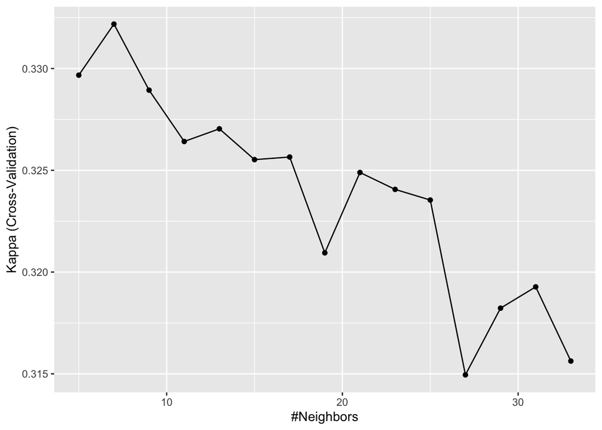

```r
ggplot(fit, metric = "Kappa")
```

```r
# Confusion Matrix
confusionMatrix(predict(fit, test),factor(test$province))
```

```
## Confusion Matrix and Statistics
##
##                    Reference
## Prediction          Burgundy California Casablanca_Valley Marlborough New_York
##   Burgundy               110         38                 3           5        1
##   California              65        607                10          19        8
##   Casablanca_Valley        2          2                 2           0        0
##   Marlborough              2          4                 1           2        1
##   New_York                 0          2                 1           5        2
##   Oregon                  59        138                 9          14       14
##                    Reference
## Prediction          Oregon
##   Burgundy              52
##   California           233
##   Casablanca_Valley      1
##   Marlborough            8
##   New_York               2
##   Oregon               251
##
## Overall Statistics
##
##                Accuracy : 0.5822
##                  95% CI : (0.5581, 0.606)
##     No Information Rate : 0.4728
##     P-Value [Acc > NIR] : < 2.2e-16
##
##                   Kappa : 0.3269
##
##  Mcnemar's Test P-Value : 6.282e-10
##
## Statistics by Class:
##
##                      Class: Burgundy Class: California Class: Casablanca_Valley
## Sensitivity                  0.46218            0.7674                 0.076923
## Specificity                  0.93101            0.6202                 0.996964
## Pos Pred Value               0.52632            0.6444                 0.285714
## Neg Pred Value               0.91257            0.7483                 0.985594
## Prevalence                   0.14226            0.4728                 0.015541
## Detection Rate               0.06575            0.3628                 0.001195
## Detection Prevalence         0.12493            0.5631                 0.004184
## Balanced Accuracy            0.69660            0.6938                 0.536944
##                      Class: Marlborough Class: New_York Class: Oregon
## Sensitivity                    0.044444        0.076923        0.4589
## Specificity                    0.990172        0.993928        0.7922
## Pos Pred Value                 0.111111        0.166667        0.5175
## Neg Pred Value                 0.974018        0.985551        0.7508
## Prevalence                     0.026898        0.015541        0.3270
## Detection Rate                 0.001195        0.001195        0.1500
## Detection Prevalence           0.010759        0.007173        0.2899
## Balanced Accuracy              0.517308        0.535426        0.6255
```

## 6. Kappa

How do we determine whether a Kappa value is represents a good or bad outcome?

> TODO: *Generally, a good Kappa value is > 0.6.*

## 7. Improvement

How can we interpret the confusion matrix, and how can we improve in our predictions?